# 5조 기대하쇼~ 쇼~ SHOW!

### - 팀 주 제 : 트렌드 분석을 통한 공연 기획

### - 개인 주제 : 트렌드 분석을 활용한 공연 기획의 필요성 (발표자 : 곽성화)

### 0. 공연의 정의

- 콘서트, 뮤지컬, 연극, 클래식, 오페라, 국악, 무용 등의 영역으로 구분
- **문화콘텐츠의 기획**, 제작, 상연, 유통과 관련된 모든 산업

```python
# 모듈 로딩
import pandas as pd                # 데이터 프라임 만드는 용도
import requests                    # 한글 깨짐 문제를 방지
from bs4 import BeautifulSoup      # 크롤링을 하기 위해
from wordcloud import WordCloud
from konlpy.tag import Okt
from collections import Counter
import matplotlib.pyplot as plt
import time
import re
import platform
import warnings
warnings.filterwarnings(action='ignore')

# 한글 깨지는 문제 해결하기위해 font_path 지정
if platform.system() == 'Windows':
    path = r'c:\Windows\Fonts\malgun.ttf'
elif platform.system() == 'Darwin': # Mac OS
    path = r'/System/Library/Fonts/AppleGothic'
else:
    path = r'/usr/share/fonts/truetype/name/NanumMyeongjo.ttf'

# Matplotlib 한글 Font 설정 ---------------
from matplotlib import font_manager as fm, rc
font_path='../Fonts/malgun.ttf'
font_name=fm.FontProperties(fname=font_path).get_name()
rc('font',family=font_name)
```

## 1-1. 3개년 공연 현황 - 데이터 전처리

```python
performDF=pd.read_csv('공연예술 결산통계.csv', skiprows=3, encoding='euc_kr')

# 자료 확인
# performDF.info()
# performDF
```

|  | 기간별 | 공연건수 | 개막편수 | 상연횟수 | 티켓판매수 | 티켓판매액 |
| --- | --- | --- | --- | --- | --- | --- |
| 0 | NaN | (건) | (편) | (회) | (건) | (천원) |
| 1 | 2019-07 | 1,147 | 928 | 8,718 | 674,526 | 16,432,380 |
| 2 | 2019-08 | 1,242 | 956 | 10,527 | 1,077,234 | 26,900,492 |
| 3 | 2019-09 | 1,274 | 988 | 7,570 | 826,272 | 23,309,533 |
| 4 | 2019-10 | 1,506 | 1,274 | 9,186 | 1,046,464 | 29,950,618 |
| 5 | 2019-11 | 1,575 | 1,310 | 9,133 | 1,092,626 | 34,615,357 |
| 6 | 2019-12 | 1,561 | 1,273 | 11,666 | 1,561,341 | 54,699,925 |
| 7 | 2020-01 | 696 | 477 | 7,866 | 1,007,537 | 40,504,364 |
| 8 | 2020-02 | 550 | 349 | 5,442 | 542,290 | 21,986,967 |
| 9 | 2020-03 | 187 | 63 | 2,268 | 162,380 | 9,190,021 |
| 10 | 2020-04 | 181 | 88 | 2,195 | 115,855 | 4,693,395 |
| 11 | 2020-05 | 340 | 224 | 3,840 | 250,744 | 11,513,176 |
| 12 | 2020-06 | 445 | 303 | 3,523 | 234,871 | 10,411,888 |
| 13 | 2020-07 | 573 | 431 | 4,526 | 393,020 | 17,162,463 |
| 14 | 2020-08 | 681 | 496 | 4,917 | 412,484 | 17,071,731 |
| 15 | 2020-09 | 290 | 178 | 2,623 | 128,772 | 7,020,444 |
| 16 | 2020-10 | 785 | 650 | 4,229 | 325,131 | 12,740,488 |
| 17 | 2020-11 | 1,165 | 980 | 5,225 | 487,734 | 15,671,208 |
| 18 | 2020-12 | 703 | 550 | 4,438 | 134,630 | 5,060,030 |
| 19 | 2021-01 | 317 | 208 | 2,582 | 110,908 | 3,747,567 |
| 20 | 2021-02 | 422 | 325 | 2,786 | 317,245 | 16,844,650 |
| 21 | 2021-03 | 710 | 609 | 3,665 | 419,053 | 21,068,437 |
| 22 | 2021-04 | 875 | 758 | 4,261 | 491,163 | 23,222,852 |
| 23 | 2021-05 | 1,060 | 892 | 5,333 | 620,044 | 26,592,645 |
| 24 | 2021-06 | 1,063 | 929 | 4,846 | 603,091 | 25,667,538 |
| 25 | 2021-07 | 1,072 | 937 | 5,801 | 575,092 | 22,995,370 |
| 26 | 2021-08 | 996 | 816 | 5,459 | 598,429 | 23,682,134 |
| 27 | 2021-09 | 1,061 | 946 | 4,803 | 588,341 | 25,724,064 |
| 28 | 2021-10 | 1,404 | 1,236 | 6,396 | 765,644 | 30,462,907 |
| 29 | 2021-11 | 1,565 | 1,415 | 6,431 | 877,613 | 34,453,774 |
| 30 | 2021-12 | 1,590 | 1,426 | 8,446 | 1,138,712 | 52,419,342 |
| 31 | 2022-01 | 691 | 537 | 6,007 | 839,083 | 42,478,961 |
| 32 | 2022-02 | 777 | 635 | 5,097 | 713,249 | 37,115,613 |
| 33 | 2022-03 | 951 | 834 | 4,960 | 626,272 | 27,594,755 |
| 34 | 2022-04 | 1,188 | 1,040 | 5,890 | 871,763 | 35,317,158 |
| 35 | 2022-05 | 1,389 | 1,182 | 6,755 | 1,155,507 | 43,047,608 |
| 36 | 2022-06 | 1,452 | 1,259 | 6,775 | 1,144,464 | 45,896,899 |

```python
# 필요하지 않은 행 삭제
performDF=performDF.drop(0).reset_index(drop=True)

# 데이터 콤마 제거후 숫자로 변경
for col in performDF.columns[1:]:
    for i in range(performDF.shape[0]):
        performDF[col][i]=performDF[col][i].replace(',','')
    performDF[col] = pd.to_numeric(performDF[col])

# 날짜를 인덱스로 설정
performDF=performDF.set_index(performDF['기간별'])

# 필요하지 않은 열 삭제
performDF.drop(['기간별'], axis=1, inplace=True)
# performDF
```

```python
# 컬럼명 변경
performDF.rename(columns={'공연건수':'공연건수(건)',
                          '개막편수':'개막편수(편)',
                          '상연횟수':'상연횟수(회)',
                          '티켓판매수':'티켓판매수(건)',
                          '티켓판매액':'티켓판매액(천원)'},inplace=True)
```

```python
pf_col= list(performDF.columns)
print(pf_col)
```

```
['공연건수(건)', '개막편수(편)', '상연횟수(회)', '티켓판매수(건)', '티켓판매액(천원)']
```

```python
# 데이터 정규화
performDF_normal = (performDF - performDF.mean())/performDF.std()
# performDF_normal
```

```python
# 그래프에 사용하기 위해 dataframe에서 list 추출
data_list = performDF_normal[pf_col[0]].to_list()

month = pd.date_range(start='2019-07', end='2022-07', freq=pd.offsets.MonthEnd(1)).strftime('%Y-%m').to_list()
# print(bike_list)
# print(month)
```

## 1-2. 3개년 공연 현황 - 기본통계

```python
for i in range(len(pf_col)):
    # 항목별 기본 통계 산출
    a=performDF[pf_col[i]]
    print(f'{pf_col[i]} 평균 => {round(a.mean())}')
    print(f'{pf_col[i]} 최대 시점 => {a.idxmax()}, {a.max():,}')
    print(f'{pf_col[i]} 최소 시점 => {a.idxmin()}, {a.min():,}')
    print('-'*40)
```

```
공연건수(건) 평균 => 930
공연건수(건) 최대 시점 => 2021-12, 1,590
공연건수(건) 최소 시점 => 2020-04, 181
----------------------------------------
개막편수(편) 평균 => 764
개막편수(편) 최대 시점 => 2021-12, 1,426
개막편수(편) 최소 시점 => 2020-03, 63
----------------------------------------
상연횟수(회) 평균 => 5672
상연횟수(회) 최대 시점 => 2019-12, 11,666
상연횟수(회) 최소 시점 => 2020-04, 2,195
----------------------------------------
티켓판매수(건) 평균 => 636933
티켓판매수(건) 최대 시점 => 2019-12, 1,561,341
티켓판매수(건) 최소 시점 => 2021-01, 110,908
----------------------------------------
티켓판매액(천원) 평균 => 24924076
티켓판매액(천원) 최대 시점 => 2019-12, 54,699,925
티켓판매액(천원) 최소 시점 => 2021-01, 3,747,567
----------------------------------------
```

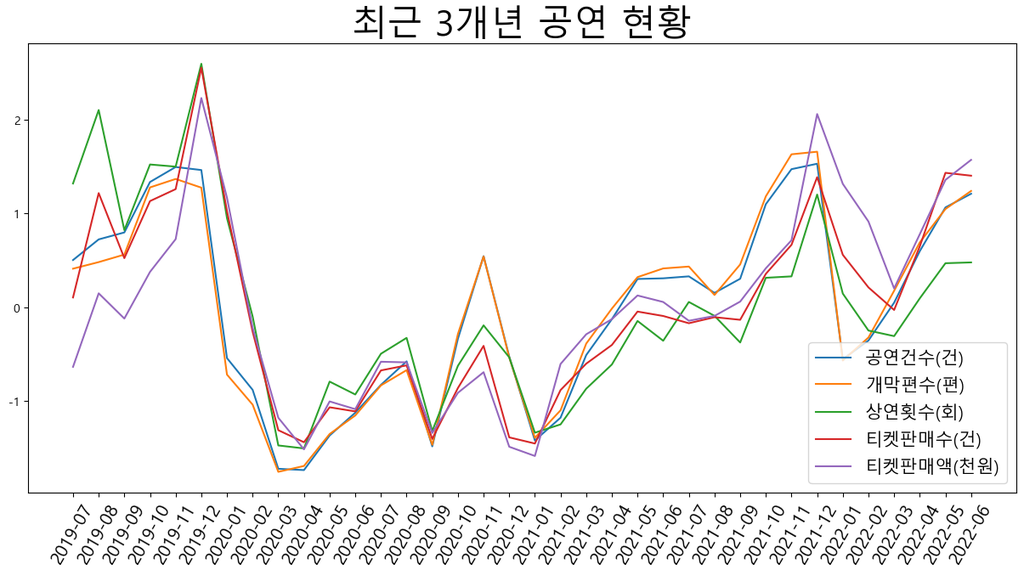

```python
# 그래프로 시각화
plt.figure(dpi=100, figsize=(15,7))

for i in range(len(pf_col)):
    plt.plot(month, performDF_normal[pf_col[i]].to_list(), label=pf_col[i], ms = 4)

plt.rcParams['axes.unicode_minus']=False    # 마이너스 기호 제대로 표시
plt.xticks(month, rotation=60, size=15)     # x축, 기울기, 글자 크기
plt.title('최근 3개년 공연 현황', fontdict={'fontsize': 30})   # 그래프 제목
plt.legend(loc=4, fontsize=15)    # 범례 위치, 글자크기
plt.show()
```

## 2-1. 공연 활성화 필요성 - 데이터 전처리

```python
# 변수 설정
end_num = 100            # 검색하려는 게시글 갯수
search_word = "공연+활성화"    # 검색어 지정
title_list = []         # 뉴스제목 리스트
sentences_tag = []      # 형태소 리스트
noun_adj_list = []      # 명사와 형용사 리스트
word_count = 20         # wordcloud로 출력하려는 단어 갯수
```

```python
# start_num ~ end_num까지 크롤링
def get_titles(start_num, end_num, search_word, title_lsit):

    while 1:
        if start_num > end_num:
            break
        url = 'https://search.naver.com/search.naver?where=news&sm=tab_jum&query={}&start={}'.format(search_word, start_num)
        req = requests.get(url)
        time.sleep(1)

        if req.ok:  # 정상적인 request 확인
            soup = BeautifulSoup(req.text, 'html.parser')

            # 뉴스제목 뽑아오기
            list_news = soup.find('ul', {'class' : 'list_news'})
            li_bxs = list_news.find_all('li', {'class': 'bx'})
            for li_bx in li_bxs:
                news_title = li_bx.find('a', {'class':'news_tit'})
                title_list.append(news_title['title'])
        start_num += 10
#     print(title_list)

# 1 ~ end_num번 게시글 까지 크롤링
get_titles(1, end_num, search_word, title_list)
```

```python
# 크롤링 데이터 DF만들기 -> csv 파일로 저장
crawlingDF = pd.DataFrame()
crawlingDF['title']=title_list
# crawlingDF

crawlingDF.to_csv('./crawling_news.csv', encoding="utf-8", index=False)
```

```python
okt = Okt()       # Open Korean Text (과거 트위터 형태소 분석기) 선언

# 형태소 분석하여 리스트에 넣기
for sentence in title_list:
    morph = okt.pos(sentence)       # 문장의 각 품사를 태깅 => 형태소 반환
    sentences_tag.append(morph)
#     print(morph)    # 형태소
#     print('-' * 30)

# print(sentences_tag)
# print('\n' * 3)

# 명사와 형용사만 구분하여 리스트에 넣기
for sentence1 in sentences_tag:
    for word, tag in sentence1:
        if tag in ['Noun', 'Adjective']:
            noun_adj_list.append(word)

# 형태소별 count
counts = Counter(noun_adj_list)
tags = counts.most_common(word_count)
# print(tags)
# print(dict(tags))    # 단어별 갯수를 딕셔너리 형태로 출력
```

[output not shown]

```python
# print(tags[0][0], tags[0][1])
crawl_word=[]    # 형태소 - 다중선택 단어
crawl_count=[]   # 형태소 - 다중선택 횟수

for i in range(len(tags)):
    crawl_word.append(tags[i][0])
    crawl_count.append(tags[i][1])

# print(crawl_word)
# print(crawl_count)
```

```python
# 크롤링 데이터 DF만들기 -> csv 파일로 저장
crawl_tagDF = pd.DataFrame()
crawl_tagDF['word']=crawl_word
crawl_tagDF['counting']=crawl_count
crawl_tagDF

crawl_tagDF.to_csv('./crawling_word.csv', encoding="utf-8", index=False)
```

## 2-2. 워드클라우드를 이용한 '공연 활성화' 주요 키워드 분석

```python
# 단어별 갯수를 딕셔너리 형태로 출력
print(dict(tags))
```

```
{'공연': 244, '활성화': 173, '문화': 73, '지역': 40, '시장': 37, '관광': 36, '버스킹': 36, '사업': 32, '상권': 29, '한국': 28, '국제': 28, '개최': 25, '추진': 25, '축제': 24, '경제': 24, '예술': 20, '지원': 20, '대학로': 16, '카드': 16, '거리': 16}
```

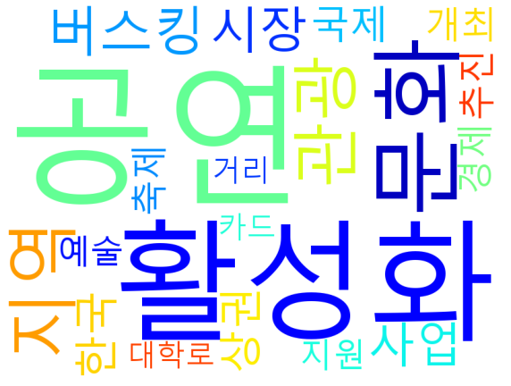

```python
# wordCloud 생성
wc = WordCloud(font_path=path, background_color='white', colormap='jet', width=800, height=600)
cloud = wc.generate_from_frequencies(dict(tags))

# 생성된 WordCloud를 perform.jpg로 보낸다.
cloud.to_file('perform_wordCloud.jpg')

plt.figure(figsize=(10, 8))
plt.axis('off')
plt.imshow(cloud)
plt.show()
```

## [결론] 공연산업을 필두로 문화, 관광 등 활성화 => 경제적 파급효과 기대

- '공연 활성화'로 수집된 리스트에서는 **'문화', '지역', '시장', '관광', '버스킹', '상권', '한국'** 등의 키워드가 높은 빈도로 도출  
  ==> 주요 키워드를 통해 '공연 활성화'가 **문화 및 관광과 밀접한 관련이 있음**
- 공연티켓 및 기획상품 판매액, 교통비, 숙박비 등 발생 => 공연을 활용한 **경제적 파급효과 기대**
- BTS 공연 1회당 경제적 파급효과 계산해보니 국내 콘서트 1회 진행 시 최대 1.2조 효과  
  출처 : https://www.mk.co.kr/news/culture/view/2022/04/354133/

## 3. 트렌드 분석을 활용한 이유

공연 연출과 티켓판매액 등 숫자로 공연에 대해 전부 설명하는 것은 한계가 있음.  
=> 그리고 그 한계를 넘어설 수 있는 것이 바로 **데이터 분석**

### 웹 크롤링을 통해 **관람객의 입장**을 고려한 방향성을 살펴보고자 함

[출처]

1. 공연 현황 - 공연예술통합전산망  
   https://www.kopis.or.kr/por/stats/perfo/prefoStatsPerformance.do?menuId=MNU_000151&searchWord=&searchType=total
2. 공연 활성화 - 네이버뉴스  
   https://search.naver.com/search.naver?where=news&sm=tab_jum&query=공연+활성화&start=1